# Data exploring and analysis

Soheil Garfami

2024-08-17

# **introduction**

Welcome to the Market Basket Analysis with R! In this markdown document, we will explore a dataset of grocery store transactions, conduct analysis, create visualizations, and derive insights. In a follow-up markdown, we will dive deeper by applying the Apriori algorithm to uncover valuable associations within the data.

### Key Objectives

The primary goals of this analysis are to:

- **Understand customer purchasing behaviors and patterns**
- **Identify key insights to enhance the shopping experience**
- **Improve product placement and identify opportunities for upselling**

### Business Questions of Interest:

Some of the key business questions we aim to answer include:

- What are the most popular items purchased, and which are the least popular?
- What does the distribution of purchased products look like?
- Are there any items that are frequently purchased together, and what are the strongest product pairings?
- How can we leverage this information to recommend additional products based on a customer’s shopping cart?

### Dataset Overview

For this analysis, we will be working with a dataset from the Instacart Market Basket Analysis competition on Kaggle [link to the dataset](https://www.kaggle.com/c/instacart-market-basket-analysis). This dataset includes the following five files, each providing valuable insights:

- **aisles.csv**: Information on the aisles where products are located.
- **departments.csv**: Details on product departments.
- **order_products.csv**: Data on the specific products purchased in each order.
- **orders.csv**: Records of customer orders.
- **products.csv**: Details on individual products.

Without further ado, let’s dive in and begin exploring the data!

# **Data exploring**

first lets import some libraries that we are going to use.

```r
library(tidyverse)
library(ggplot2)
library(DataExplorer)
library(lubridate)
```

Importing Datasets:

```r
orders_products <- read.csv("data/order_products__train.csv")
orders <- read.csv("data/orders.csv")
products <- read.csv("data/products.csv")
aisles <- read.csv("data/aisles.csv")
departments <- read.csv("data/departments.csv")
```

### Dataset: order_products

Let’s take a look at this dataset.

```r
glimpse(orders_products)
```

```
## Rows: 1,384,617
## Columns: 4
## $ order_id          <int> 1, 1, 1, 1, 1, 1, 1, 1, 36, 36, 36, 36, 36, 36, 36, …
## $ product_id        <int> 49302, 11109, 10246, 49683, 43633, 13176, 47209, 220…
## $ add_to_cart_order <int> 1, 2, 3, 4, 5, 6, 7, 8, 1, 2, 3, 4, 5, 6, 7, 8, 1, 2…
## $ reordered         <int> 1, 1, 0, 0, 1, 0, 0, 1, 0, 1, 0, 1, 1, 1, 1, 1, 0, 0…
```

Let’s examine how many orders and products we have.

```r
length(unique(orders_products$order_id))
```

```
## [1] 131209
```

```r
length(unique(orders_products$product_id))
```

```
## [1] 39123
```

**Let’s examine the distribution of the number of products in orders.**

```r
n_product_by_orders <- orders_products %>%
  group_by(order_id) %>%
  summarise(n_product= n())


summary(n_product_by_orders$n_product)
```

```
##    Min. 1st Qu.  Median    Mean 3rd Qu.    Max.
##    1.00    5.00    9.00   10.55   14.00   80.00
```

As you can see, the minimum number of products in an order is 1, while the maximum is 80. Let’s explore some `visualizations` to gain further insights.

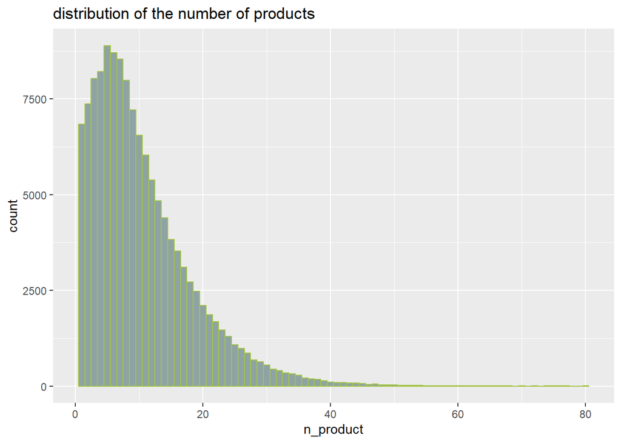

```r
n_product_by_orders %>%
  ggplot(aes(n_product))+
  geom_histogram(binwidth = 1 ,fill="#8ea3a3" , color='#a4c445')+
  labs(title = "distribution of the number of products")
```

Let’s create a report for this dataset.

```r
create_report(orders_products,
              output_file = "reports/orders_products_report.html",
              y = NULL,
              config = configure_report(add_plot_missing = F,
                                        add_plot_intro=F,
                                        add_plot_str = F,
                                        add_plot_correlation = F,
              )
)
```

take a look at the report for order-product

```r
#Since we no longer need the variable `n_product_by_orders`, let's remove it from memory to clean up.

rm(n_product_by_orders)
```

### Dataset: orders

```r
head(orders)
```

```
##   order_id user_id eval_set order_number order_dow order_hour_of_day
## 1  2539329       1    prior            1         2                 8
## 2  2398795       1    prior            2         3                 7
## 3   473747       1    prior            3         3                12
## 4  2254736       1    prior            4         4                 7
## 5   431534       1    prior            5         4                15
## 6  3367565       1    prior            6         2                 7
##   days_since_prior_order
## 1                     NA
## 2                     15
## 3                     21
## 4                     29
## 5                     28
## 6                     19
```

**Let’s analyze the time intervals between orders**

```r
summary(orders$days_since_prior_order)
```

```
##    Min. 1st Qu.  Median    Mean 3rd Qu.    Max.    NA's
##    0.00    4.00    7.00   11.11   15.00   30.00  206209
```

```r
#Let's see the percentage of data entries without `days_since_prior_order`.
round(sum(is.na(orders$days_since_prior_order))/nrow(orders) , 2)
```

```
## [1] 0.06
```

Some of these missing values might be due to first-time purchases, but overall, it’s not a large proportion.

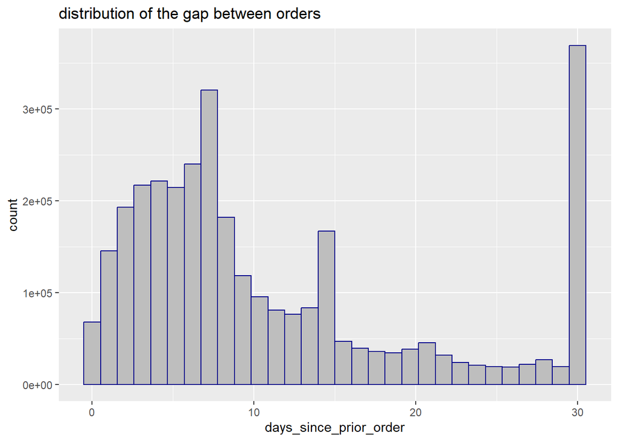

```r
ggplot(orders , aes(days_since_prior_order))+geom_histogram(fill="gray" , color="darkblue" )+
  labs(title = "distribution of the gap between orders")
```

**Let’s see the distribution of orders by hour of the day.**

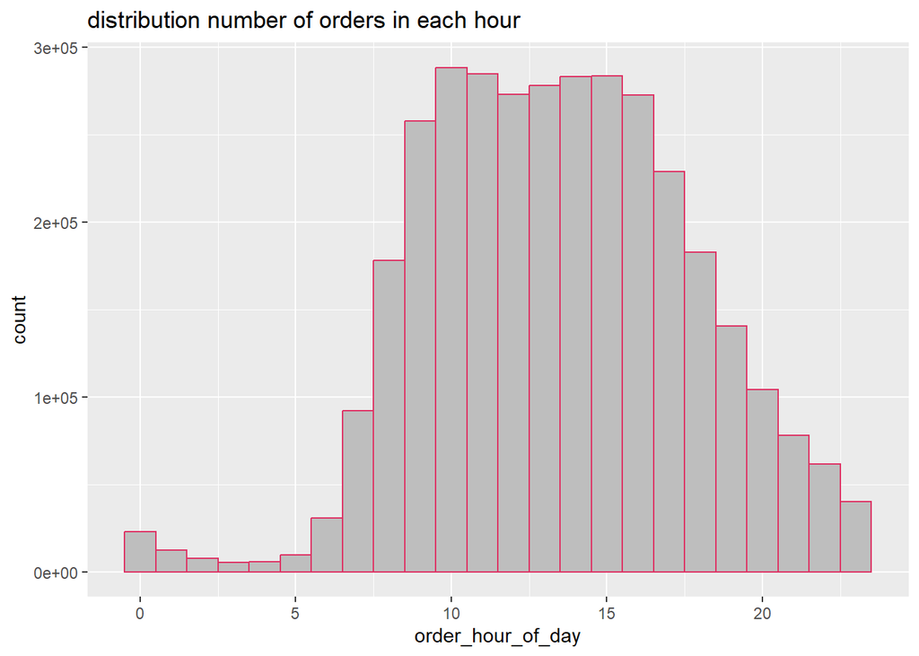

```r
ggplot(orders , aes(order_hour_of_day))+geom_histogram(fill="gray" ,binwidth = 1, color="#DE3163" )+
  labs(title = "distribution number of orders in each hour")
```

**orders in days of the week**

[figure not shown]

```r
hist(orders$order_dow,          # "Suggests" 14 bins
     freq   = FALSE,       # Axis shows density, not freq.
     col    = "thistle1",  # Color for histogram
     main   = paste("Histogram of Annual Canadian Lynx",
                    "Trappings, 1821-1934"),
     xlab   = "Number of Lynx Trapped")
```

it seems like we get a few more orders in the first tow days of the week

```r
create_report(orders,
              output_file = "reports/orders.html",
              y = NULL,
              config = configure_report(
                                        add_plot_intro=F,
                                        add_plot_str = F,
              ))
```

check out the report for the orders

### Dataset: products

have look at the data set

```r
glimpse(products)
```

```
## Rows: 49,688
## Columns: 4
## $ product_id    <int> 1, 2, 3, 4, 5, 6, 7, 8, 9, 10, 11, 12, 13, 14, 15, 16, 1…
## $ product_name  <chr> "Chocolate Sandwich Cookies", "All-Seasons Salt", "Robus…
## $ aisle_id      <int> 61, 104, 94, 38, 5, 11, 98, 116, 120, 115, 31, 119, 11, …
## $ department_id <int> 19, 13, 7, 1, 13, 11, 7, 1, 16, 7, 7, 1, 11, 17, 18, 19,…
```

Let’s examine the proportion of products that are `organic` versus `non-organic`.

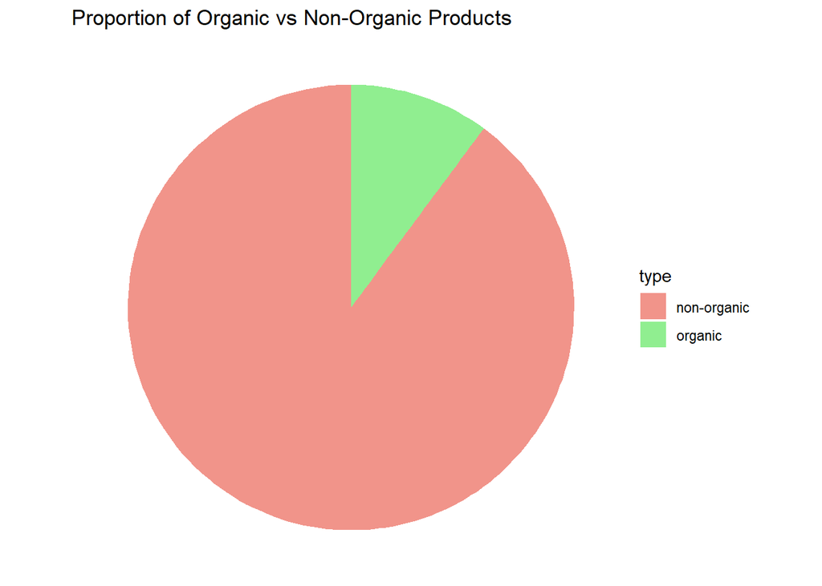

```r
products %>%
  mutate(type = ifelse(grepl("Organic", product_name) , "organic" ,"non-organic")) %>%
  group_by(type) %>%
  summarise(count = n(), .groups = 'drop') %>%  # Added .groups = 'drop' to avoid warning
  ggplot(aes(x = "", y = count, fill = type)) +
  geom_bar(width = 1, stat = "identity") +
  coord_polar(theta = "y") +
  labs(title = "Proportion of Organic vs Non-Organic Products") +
  theme_void() +
  scale_fill_manual(values = c("organic" = "lightgreen", "non-organic" = "#f1948a"))
```

```r
create_report(orders,
              output_file = "reports/products_report.html" ,
              y = NULL,  )
```

### Dataset: aisles and departments

```r
head(aisles)
```

```
##   aisle_id                      aisle
## 1        1      prepared soups salads
## 2        2          specialty cheeses
## 3        3        energy granola bars
## 4        4              instant foods
## 5        5 marinades meat preparation
## 6        6                      other
```

```r
head(departments)
```

```
##   department_id    department
## 1             1        frozen
## 2             2         other
## 3             3        bakery
## 4             4       produce
## 5             5       alcohol
## 6             6 international
```

Let’s now join all the datasets together to build a complete dataset.

```r
JOINED <- inner_join(orders_products , orders , by="order_id")
JOINED <- inner_join(JOINED , products , "product_id")
JOINED <- inner_join(JOINED , aisles , "aisle_id")
JOINED <- inner_join(JOINED , departments , "department_id")

write.csv(JOINED , "data/JOINED.csv" , row.names = F)

View(head(JOINED))
```

```r
ncol(JOINED)
```

```
## [1] 15
```

```r
nrow(JOINED)
```

```
## [1] 1384617
```

# **Analizing the Data**

Now, we are going to use the joined dataset to uncover `insights` and create `visualizations`.

let’s build a frequency table and see the most popular products

```r
frequency_product <- JOINED %>%
  group_by(product_name ) %>%
  summarise(count = n()) %>%
  arrange(desc(count))

top_n(frequency_product , 10)
```

```
## # A tibble: 10 × 2
##    product_name           count
##    <chr>                  <int>
##  1 Banana                 18726
##  2 Bag of Organic Bananas 15480
##  3 Organic Strawberries   10894
##  4 Organic Baby Spinach    9784
##  5 Large Lemon             8135
##  6 Organic Avocado         7409
##  7 Organic Hass Avocado    7293
##  8 Strawberries            6494
##  9 Limes                   6033
## 10 Organic Raspberries     5546
```

yeyy banana , I love banana :)

lets see the most popular aisles

```r
frequency_aisle <- JOINED %>%
  group_by(aisle ) %>%
  summarise(count = n()) %>%
  arrange(desc(count))

top_n(frequency_aisle , 10)
```

```
## # A tibble: 10 × 2
##    aisle                          count
##    <chr>                          <int>
##  1 fresh vegetables              150609
##  2 fresh fruits                  150473
##  3 packaged vegetables fruits     78493
##  4 yogurt                         55240
##  5 packaged cheese                41699
##  6 water seltzer sparkling water  36617
##  7 milk                           32644
##  8 chips pretzels                 31269
##  9 soy lactosefree                26240
## 10 bread                          23635
```

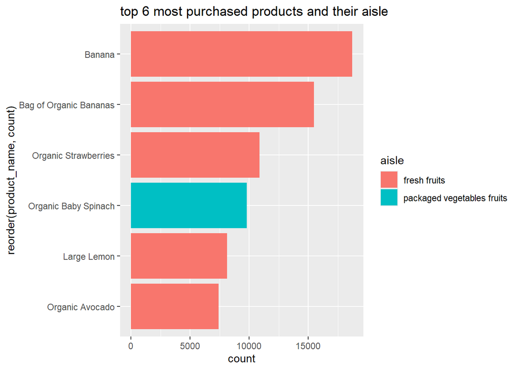

```r
JOINED %>%
  group_by(product_name, aisle ) %>%
  summarise(count = n()) %>%
  arrange(desc(count)) %>%
  head() %>%
  ggplot(aes(x = reorder(product_name , count) , y = count, fill = aisle))+
  geom_bar(stat = "identity")+
  coord_flip()+
  labs(title = "top 6 most purchased products and their aisle")
```

Let’s check if there are any products that were purchased only once.

```r
frequency_product %>%
  filter(count == 1)
```

```
## # A tibble: 7,884 × 2
##    product_name                                      count
##    <chr>                                             <int>
##  1 #2 Cone White Coffee Filters                          1
##  2 #2 Mechanical Pencils                                 1
##  3 +Energy Black Cherry Vegetable & Fruit Juice          1
##  4 1 Step-1 Minute Noodles Toasted Sesame                1
##  5 1% Hydrocortisone Anti-Itch Cream, Tube Anti-Itch     1
##  6 1% Lowfat Cultured Buttermilk                         1
##  7 1% Lowfat Vanilla Milk                                1
##  8 1,000 Mg Vitamin C Super Orange                       1
##  9 1/4 Pound Burgers                                     1
## 10 10 Tostada Shells                                     1
## # ℹ 7,874 more rows
```

Let’s examine the percentage of one-time-purchased products in the dataset.

```r
frequency_product %>%
  filter(count == 1) %>%
  nrow() / nrow(frequency_product)
```

```
## [1] 0.2015183
```

```r
frequency_product <-  frequency_product %>%
  mutate(percent = count / nrow(frequency_product)) %>%
  mutate(rank = rank(desc(count)))

head(frequency_product)
```

```
## # A tibble: 6 × 4
##   product_name           count percent  rank
##   <chr>                  <int>   <dbl> <dbl>
## 1 Banana                 18726   0.479     1
## 2 Bag of Organic Bananas 15480   0.396     2
## 3 Organic Strawberries   10894   0.278     3
## 4 Organic Baby Spinach    9784   0.250     4
## 5 Large Lemon             8135   0.208     5
## 6 Organic Avocado         7409   0.189     6
```

Let’s examine the number of purchases made by each customer and sort them from highest to lowest to identify the maximum.

```r
JOINED %>%
  group_by(user_id ) %>%
  summarise(numberOfPurches = n()) %>%
  arrange(desc(numberOfPurches))
```

```
## # A tibble: 131,209 × 2
##    user_id numberOfPurches
##      <int>           <int>
##  1  149753              80
##  2  197541              80
##  3   63458              77
##  4   83993              76
##  5  189951              76
##  6  169647              75
##  7   31611              74
##  8  104741              74
##  9   59321              72
## 10  181991              72
## # ℹ 131,199 more rows
```

Now that we have a good understanding of the data and have extracted some valuable insights, the next step is to conduct a market basket analysis to discover potential correlation rules.

Check out the Market Basket Analysis kernel.